# Part 2 - Working with Factors

Ted Laderas

5/18/2017

In this section, we’ll learn some skills about manipulating factor (categorical) data.

We’ll do this by making a bar plot and a box plot and progressively making it more complex.

## Reviewing Factors

Factors are how R represents categorical data.

There are two kinds of factors:

- `factor` - used for *nominal* data (“Ducks”,“Cats”,“Dogs”)
- `ordered`- used for *ordinal* data (“10-30”,“31-40”,“41-60”)

We’ll manipulate our barplot and add more information using factors.

```r
library(tidyverse)

##make our table of pets
pets <- data.frame(id=c('C1','C2','D1','D4','D8', 'C4', 'D5',
                        'C10', "G4", "C11", "D9", "C6"),
                name=factor(c("Morris", "Morris", "Fido", "Mr Bowser",
                              "Fido", "Lady Sheba", "Hubert", "Apples", "Nibbles",
                              "Morris", "Winky", "Fido")),
                ##weight is in pounds
                weight=c(6,7,15,20,40, 10, 60, 17, 0.5, 10, 11, 6),
                animal=factor(c("cat", "cat", "dog", "dog", "dog",
                                "cat", "dog", "cat", "gerbil", "cat", "dog", "cat")),
                ##because it's an ordered category, we have to specify
                ##order as the levels argument
                ageCategory= ordered(c("0-2", "5-8", "5-8", "3-4", "3-4",
                                       "5-8", "0-2", "5-8", "0-2","5-8", "3-4", "5-8"),
                                       levels=c("0-2", "3-4", "5-8")),
                shotsCurrent=c("No", "Yes", "No", "No", "Yes", "No",
                               "No", "Yes", NA, "No", "No", "Yes"))

pets
```

```
##     id       name weight animal ageCategory shotsCurrent
## 1   C1     Morris    6.0    cat         0-2           No
## 2   C2     Morris    7.0    cat         5-8          Yes
## 3   D1       Fido   15.0    dog         5-8           No
## 4   D4  Mr Bowser   20.0    dog         3-4           No
## 5   D8       Fido   40.0    dog         3-4          Yes
## 6   C4 Lady Sheba   10.0    cat         5-8           No
## 7   D5     Hubert   60.0    dog         0-2           No
## 8  C10     Apples   17.0    cat         5-8          Yes
## 9   G4    Nibbles    0.5 gerbil         0-2         <NA>
## 10 C11     Morris   10.0    cat         5-8           No
## 11  D9      Winky   11.0    dog         3-4           No
## 12  C6       Fido    6.0    cat         5-8          Yes
```

## A basic bar plot

The `geom_bar()` default is to count the number of values with each factor level. Note that you don’t map to a y-aesthetic here, because the y values are the counts.

Given this dataset, we might want to ask how many pets have the same name. What is the most popular name?

Try mapping another variable to `fill` (try both `weight` and `animal`). Are the results what you expected?

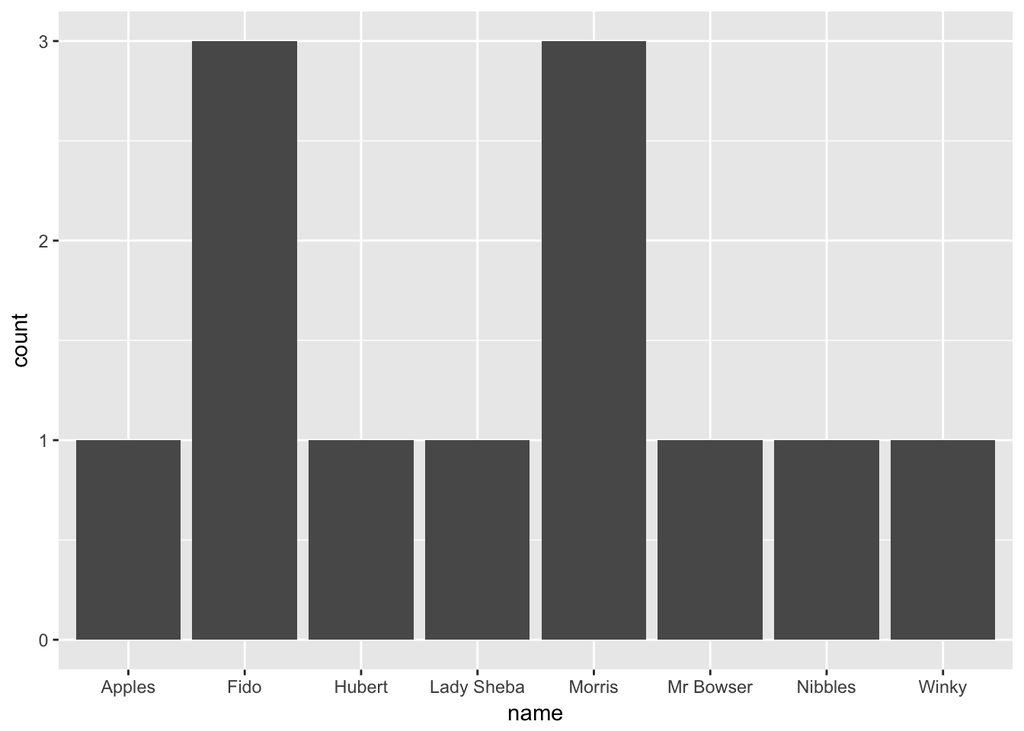

```r
ggplot(pets, aes(x=name)) + geom_bar()
```

## Faceting

Say you have another `factor` variable and you want to stratify the plots based on that. You can do that by supplying the name of that variable as a facet.

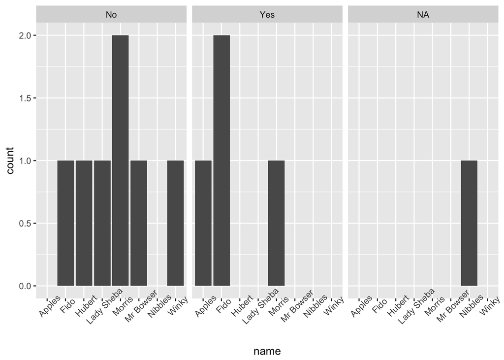

```r
ggplot(pets, aes(x=name)) + geom_bar() +
  ## have to specify facets using notation
  ## try out facets=~ageCategory!
  facet_wrap(facets=~shotsCurrent) +
  ## we make the x axis x angled for better legibility
  theme(axis.text.x = element_text(angle=45))
```

You might notice that there are blank spots for the categories in each facet. We can restrict factors in each by using `scale="free_x"` argument in `facet_wrap()`.

How many animals named “Morris” did not receive shots?

What happens when you replace the `scale` argument with “free_y”?

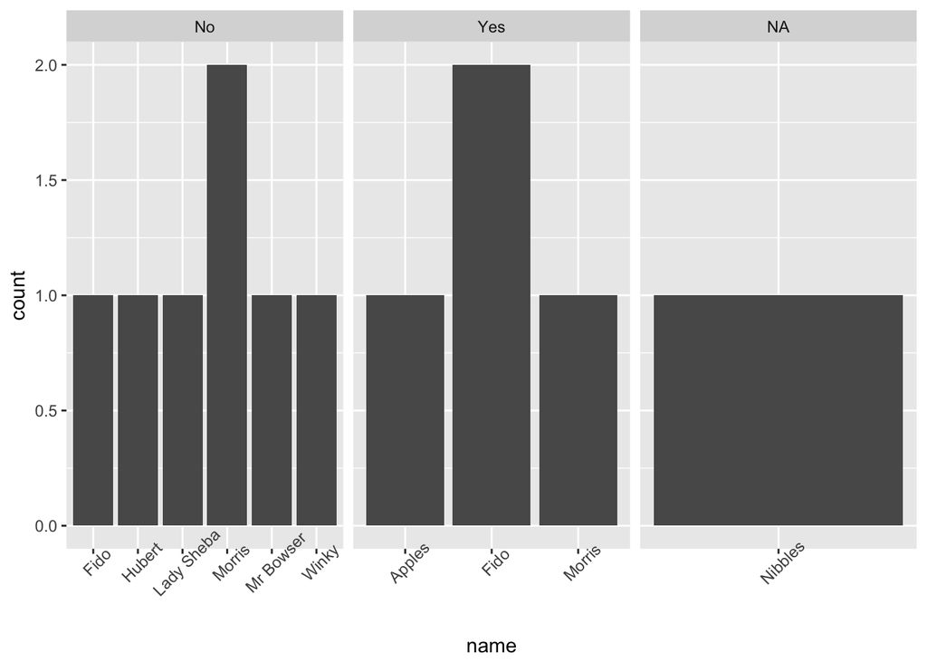

```r
ggplot(pets, aes(x=name)) + geom_bar() +
  facet_wrap(facets=~shotsCurrent, scale="free_x") +
  theme(axis.text.x = element_text(angle=45))
```

## Stacked Bars

Let’s see how many of each animal got shots. We can do this by mapping `shotsCurrent` to `fill`.

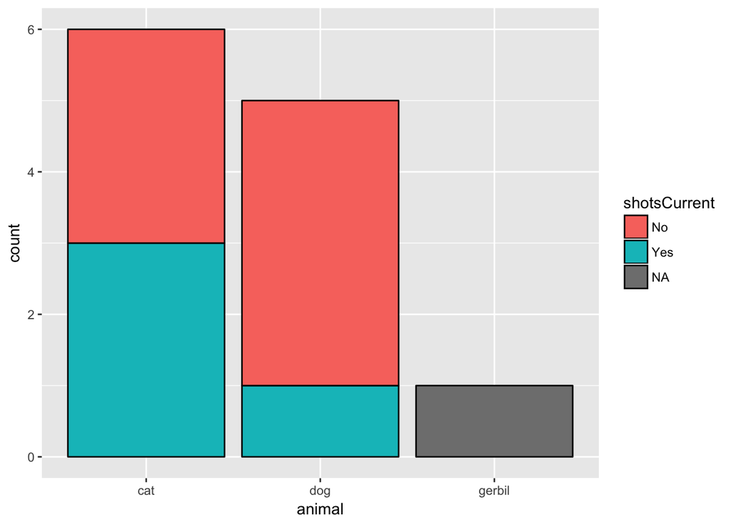

```r
#we map color (the outline of the plot) to black to make it look prettier
ggplot(pets, aes(x=animal,fill=shotsCurrent)) + geom_bar(color="black")
```

## Proportional Barchart

We may only be interested in the relative proportions between the different categories. Visualizing this is useful for various 2 x 2 tests on proportions.

What percent of dogs did not recieve shots?

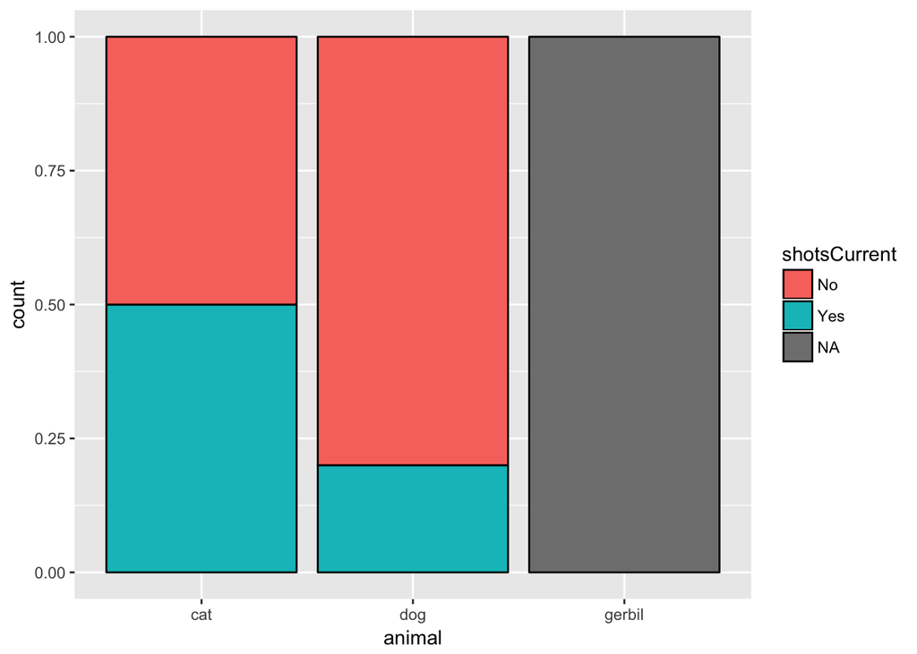

```r
ggplot(pets, aes(x=animal,fill=shotsCurrent)) +
  geom_bar(position = "fill", color = "black")
```

## Dodge those bars!

Instead of stacking, we can also dodge the bars (move the bars so they’re beside each other).

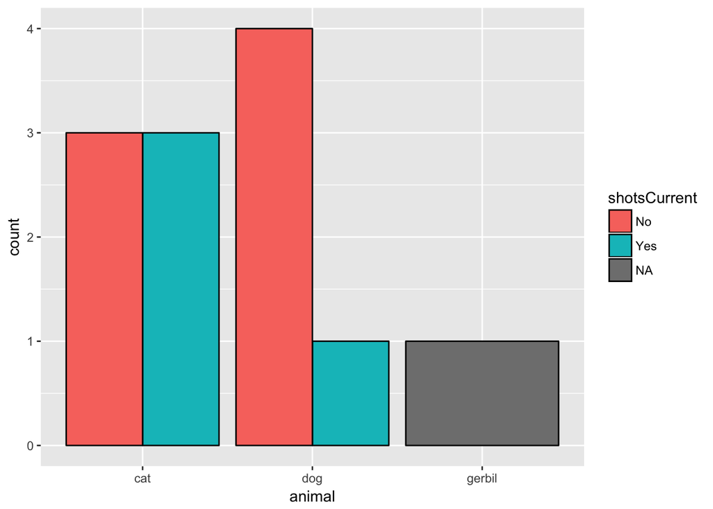

```r
ggplot(pets, aes(x=animal,fill=shotsCurrent)) +
  geom_bar(position="dodge", color="black")
```

## Your Task

Given the `pets` `data.frame`, plot a stacked proportional barchart showing that shows the age category counts by animal type. Is the proportion of animals receiving shots the same across each age category?

Intermediate Folks: facet this plot by `shotsCurrent`.

```r
#Space for your answer here.
```

## Boxplots

Boxplots allow us to assess distributions of a continuous variable conditioned on categorical variables.

What does this tell us?

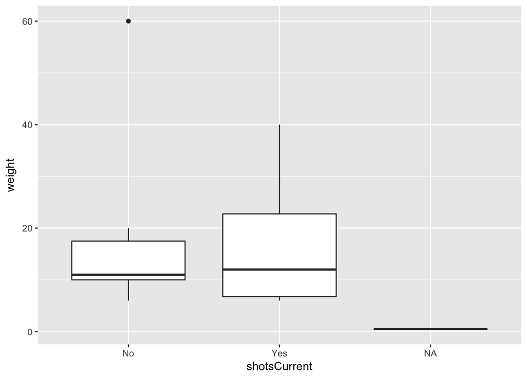

```r
ggplot(pets, aes(x=shotsCurrent, y=weight)) + geom_boxplot()
```

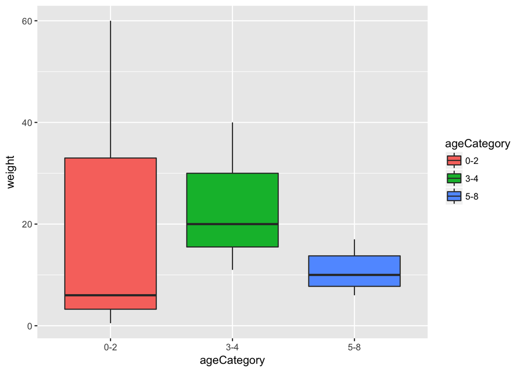

```r
ggplot(pets, aes(x=ageCategory, y=weight, fill=ageCategory)) + geom_boxplot()
```

## Your task: How heavy are our pets?

Visualize `weight` by `animal` type as both a boxplot and a violin plot. What do you conclude? Which kind of animal weighs more on average than the other?

Intermediate users: How would we plot both boxplots and a violin plot on the same graph?

```r
##Space for your answer here
```

## (Optional) More on manipulating factors

The following section is optional. Intermediate users may find these helpful.

You’ll need to load the `forcats` package to use these.

```r
library(forcats)
```

## Let’s build a bar plot

To start out, let’s plot the weight for each pet as a bar graph.

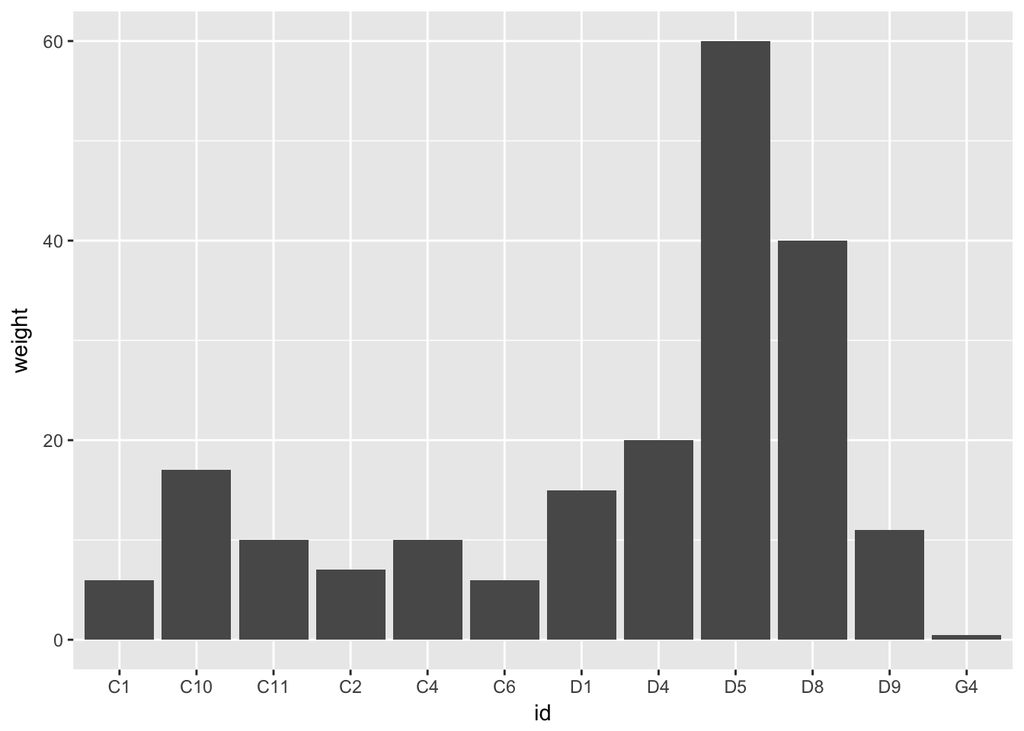

```r
ggplot(data=pets, aes(x=id,y=weight)) + geom_bar(stat="identity")
```

## Sort by another variable (intermediate)

Let’s sort the barplot by weight. We can do this by adding a `fct_reorder()` expression to define a new variable `id2` whose categories are ordered by `weight`.

Based on this visualization, what can we conclude about the weights of each type of animal? Which kind of animal weighs the most?

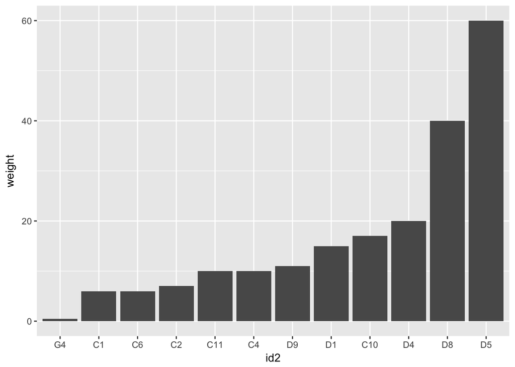

```r
pets %>% mutate(id2=fct_reorder(id, weight)) %>%
  ggplot(aes(x=id2,y=weight)) +
  geom_bar(stat="identity")
```

## Plot in Reverse Alphabetical Order

Often, you want to plot things in reverse alphametical order. This is useful because heatmaps and such are often plotted from the bottom.

You can use `fct_rev` to do this.

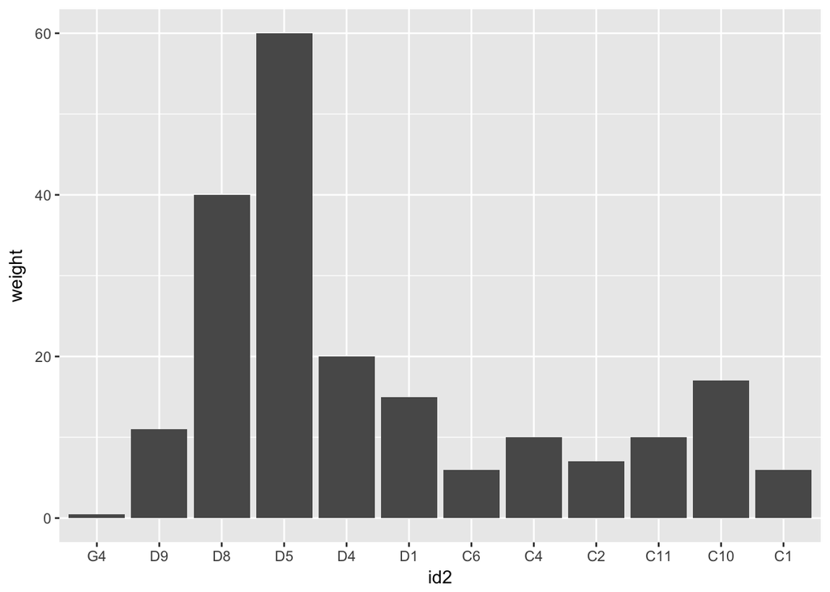

```r
library(forcats)
pets %>% mutate(id2=fct_rev(id))%>%
  ggplot(aes(x=id2,y=weight)) +
  geom_bar(stat="identity")
```

## Sort by frequency

Going back to our `pets` data, sometimes we want to sort our count data by frequency. We can use `fct_infreq()` to do that.

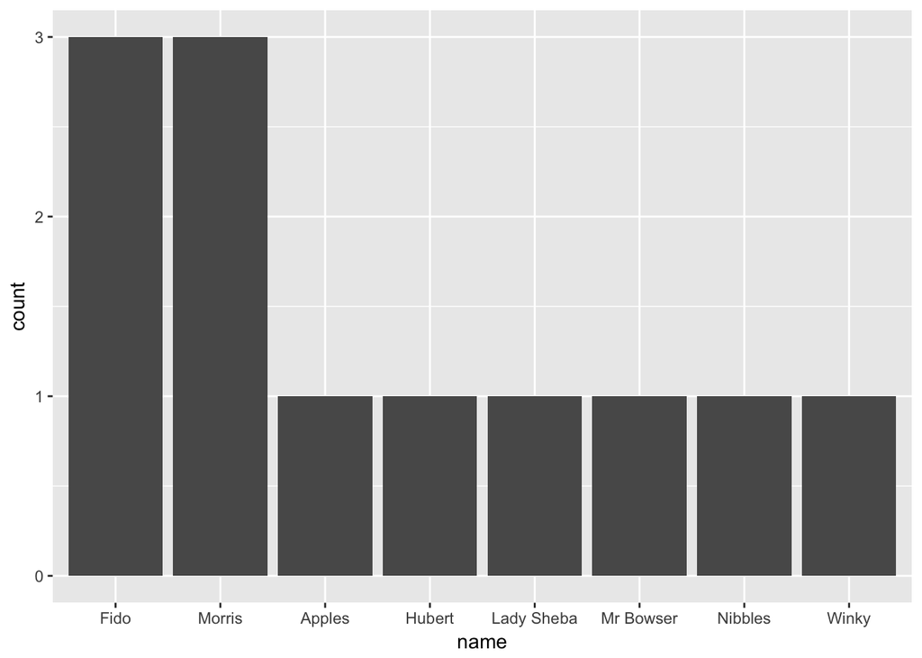

```r
pets %>% mutate(name = fct_infreq(name)) %>% ggplot(aes(x=name)) + geom_bar()
```

## Recode levels of a factor

## Group levels of a factor together

## Making an “other” category (intermediate)

Say we’re only interested in comparing young animals (`0-2`) to the older animals. We can use `fct_other()`.